# Tech Work by Job Class

Ryan Burge

March 8, 2018

## Here’s what I Did

I wanted to start by breaking the Occupational Codes into their major groups to get a sense of which ones are using technology the most at work. These are the headings given by the Census Bureau.

```r
gss <- gss %>%
  mutate(newocc = recode(occ10, "0:999 = 'Management';
                                  1000:1999 = 'Technology, Engineering and Science';
                                  2000:2999 = 'Education, Legal, Media';
                                  3000:3540 = 'Health and Technology';
                                  3600:4650 = 'Service';
                                  4700:4999 = 'Sales';
                                  5000:5999 = 'Office and Admin Support';
                                  6000:7630 = 'Construction and Maintenance';
                                  7700:9750 = 'Production and Transportation';
                                  9800:9830 = 'Military'"))
```

```r
mean <- gss %>%
  group_by(newocc) %>%
  summarise(mean = mean(usetech, na.rm = TRUE),
            sd = sd(usetech, na.rm = TRUE),
            n = n()) %>%
  mutate(se = sd/sqrt(n),
         lower = mean - qt(1 - (0.05 /2),  n -1) * se,
         upper = mean + qt(1 - (0.05 /2),  n -1) * se)

mean <- mean %>%
  mutate(newocc = as.factor(newocc)) %>% na.omit()

mean$class <- c("Low", "High", "High", "High", "Low", "Low", "Low", "Low", "Low", "High")
```

I wanted to calcuate the mean of “usetech” for each of the ten occupational classes and then I wanted to compare that to the typology used in the “CyberSlacking” piece. They said that four occupational classes are high tech ones: management, business, financial, or professional. I marked each of those as low or high. Here’s the graph

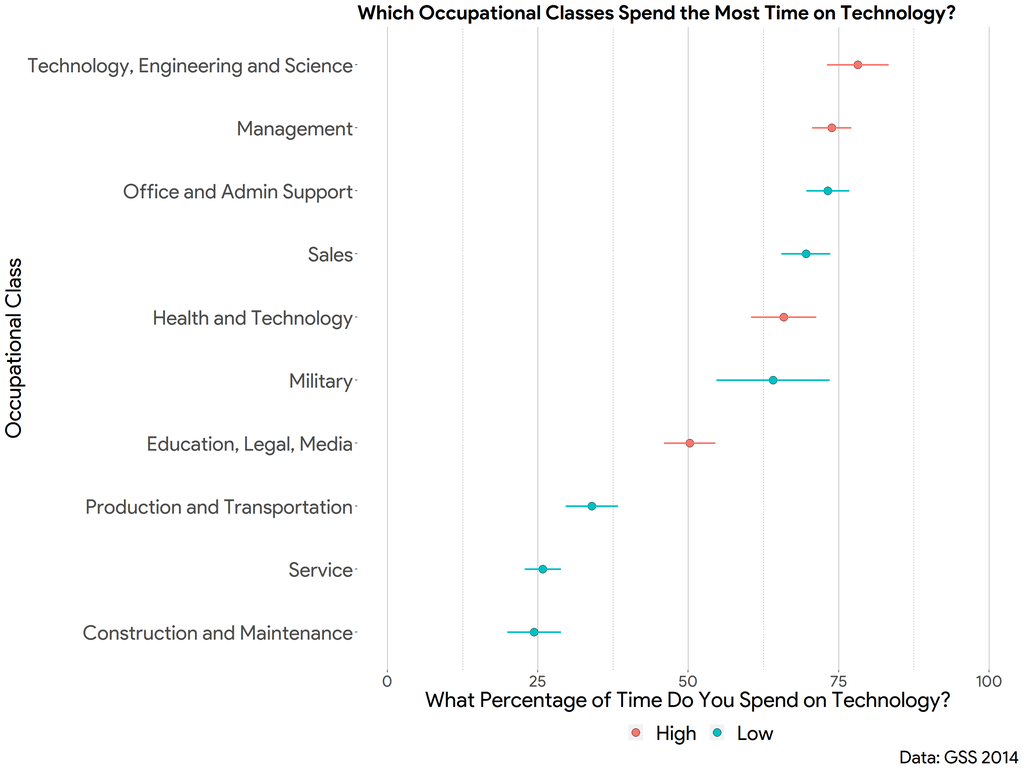

```r
mean %>%
  ggplot(., aes(x= mean, y= fct_reorder(newocc, mean))) +
  geom_point(shape=21, size =4, aes(fill = factor(class)), show.legend = TRUE) +
  geom_errorbarh(aes(xmin = lower, xmax=upper, colour = factor(class)), height=0, size = 1, show.legend = FALSE) +
  mean_rb() +
  scale_x_continuous(limits = c(0, 100)) +
  labs(x = "What Percentage of Time Do You Spend on Technology?", y = "Occupational Class", title = "Which Occupational Classes Spend the Most Time on Technology?", caption = "Data: GSS 2014")
```

## So, what do we do?

It’s clear that the distinction used in “Cyberslacking” is not backed up by this data. We need to create division. Could be dichotomous or trichotomous. We need to make a cutoff point.

Two possibilities:

1. Take health and technology and everything above that and code as high technology use. Everything below would be low technology use.
2. Do a trichotomous. It’s clear that the bottom three are clearly lower than the rest. Middle category is education + military + health. Top category is the top 4.

What do you think?